# 471-Final

Zhoumengdi Wang (zxw534)

```r
library(tree)
library(randomForest)
library(caret)
library(xgboost)
library(e1071)
```

# Load Data

```r
trainset=read.table('trainset', header = T)
testset=read.table('testset', header = T)
```

First of all, we check if there is any missing.

```r
anyNA(trainset)
```

```
## [1] FALSE
```

```r
anyNA(testset)
```

```
## [1] FALSE
```

Because the original data is not numerical, so I have to transfor the data into numerical data.

```r
train =as.matrix(trainset)
mean(sapply(train, is.numeric))
```

```
## [1] 1
```

```r
test =as.matrix(testset)
mean(sapply(test, is.numeric))
```

```
## [1] 1
```

Get the bankrupt data from the trainset.

```r
train.y = train[,55]
train.x = train[,c(1:54)]
test.y = test[,55]
test.x = test[,c(1:54)]
```

```r
train.y = as.factor(train.y)
test.y = as.factor(test.y)
```

# 1.Random Forest

```r
set.seed(0)
rf = randomForest(train.x,train.y,mtry = 10,ntree = 10)
```

```r
rf.pred = predict(rf, test.x, type = "class")
score = table(rf.pred, test.y)
score
```

```
##        test.y
## rf.pred    0    1
##       0 1741  106
##       1   36   36
```

```r
accuracy = (score[1,1] + score[2,2])/(score[1,2] + score[2,1] + score[1,1] +
                                               score[2,2])
accuracy
```

```
## [1] 0.9260031
```

The accuracy of the Random Forest model is 92.60%.

```r
levels(train.y) <- c("Type1", "Type2")
```

## Improve model

In order to improve the model, I decide to do cross-validation and chose the best metry.

```r
cv = trainControl(method="repeatedcv",repeats=5, classProbs=TRUE)
set.seed(0)

cv.rf = train(x=train.x, y=train.y, trControl=cv, tuneGrid=data.frame(mtry=1:25), method="rf", ntree=100)
```

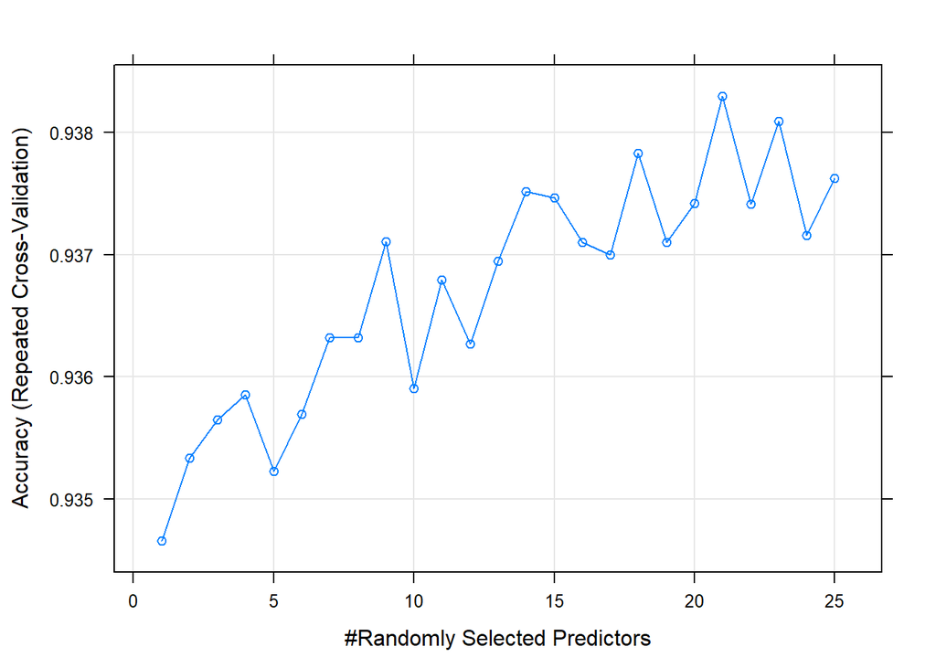

```r
plot(cv.rf)
```

According to the plot, the optimal mtry is 21. Using the best mtry to do the test again.

```r
rf.test.pred = predict(cv.rf$finalModel, test.x)
score = table(rf.test.pred, test.y)
score
```

```
##             test.y
## rf.test.pred    0    1
##        Type1 1750  107
##        Type2   27   35
```

```r
accuracy = (score[1,1] + score[2,2])/(score[1,2] + score[2,1] + score[1,1] +
                                               score[2,2])
accuracy
```

```
## [1] 0.930172
```

The accuracy now is 93.02%, better than 92.60%.

# 2. Boosting

```r
train.y = train[,55]
```

```r
set.seed(0)
bst1 = xgboost(data = train.x, label = train.y, max_depth=4,eta = 1, nround = 5, objective = "binary:logistic")
test.y = test[,55]
score = table(predict(bst1,test.x)>0.5,test.y)
score
```

```
##        test.y
##            0    1
##   FALSE 1731   90
##   TRUE    46   52
```

```r
accuracy = (score[1,1] + score[2,2])/(score[1,2] + score[2,1] + score[1,1] +
                                               score[2,2])
accuracy
```

```
## [1] 0.9291298
```

The accuracy is 92.91%

## Improve model

In bossting model,I decide to find better max_depth,eta and nround. After trying different parameters, the better max_depth,eta and nround is 5,0.1,50

```r
bst2 = xgboost(data = train.x, label = train.y, max_depth=5,eta = 0.1, nround = 50, objective = "binary:logistic")
test.y = test[,55]
score = table(predict(bst2,test.x)>0.5,test.y)
score
```

```
##        test.y
##            0    1
##   FALSE 1759   95
##   TRUE    18   47
```

```r
accuracy = (score[1,1] + score[2,2])/(score[1,2] + score[2,1] + score[1,1] +
                                               score[2,2])
accuracy
```

```
## [1] 0.9411152
```

The accuracy now is 94.11%, better than last boosting model and the accuracy is also better than Random Forest.

# SVM

```r
train.y = train[,55]
test.y = test[,55]
train.y = as.factor(train.y)
test.y = as.factor(test.y)
```

Firstly, I use the same parameters in homwork 3.

```r
svm1 = svm(x = train.x,y = train.y,kernel ="linear", cost=0.01, scale=F)
summary(svm1)
```

```
##
## Call:
## svm.default(x = train.x, y = train.y, scale = F, kernel = "linear",
##     cost = 0.01)
##
##
## Parameters:
##    SVM-Type:  C-classification
##  SVM-Kernel:  linear
##        cost:  0.01
##       gamma:  0.01851852
##
## Number of Support Vectors:  28
##
##  ( 13 15 )
##
##
## Number of Classes:  2
##
## Levels:
##  0 1
```

```r
svm.test.pred = predict(svm1, test.x)
score = table(svm.test.pred, test.y)
score
```

```
##              test.y
## svm.test.pred    0    1
##             0 1739  141
##             1   38    1
```

```r
accuracy = (score[1,1] + score[2,2])/(score[1,2] + score[2,1] + score[1,1] +
                                               score[2,2])
accuracy
```

```
## [1] 0.9067223
```

The accuracy is 90.67%.

## Improve model

### change kernel

```r
svm1 = svm(x = train.x,y = train.y,kernel ="radial", cost=0.01, scale=F)
summary(svm1)
```

```
##
## Call:
## svm.default(x = train.x, y = train.y, scale = F, kernel = "radial",
##     cost = 0.01)
##
##
## Parameters:
##    SVM-Type:  C-classification
##  SVM-Kernel:  radial
##        cost:  0.01
##       gamma:  0.01851852
##
## Number of Support Vectors:  3799
##
##  ( 3537 262 )
##
##
## Number of Classes:  2
##
## Levels:
##  0 1
```

```r
svm.test.pred = predict(svm1, test.x)
score = table(svm.test.pred, test.y)
score
```

```
##              test.y
## svm.test.pred    0    1
##             0 1777  142
##             1    0    0
```

```r
accuracy = (score[1,1] + score[2,2])/(score[1,2] + score[2,1] + score[1,1] +
                                               score[2,2])
accuracy
```

```
## [1] 0.9260031
```

In this kernel function, although the accuracy is higher than before, but look at the result, the model just gives the prediction with all 0, this is a bad model.

```r
grid.c=expand.grid(C = seq(0.01,10,length.out = 10))
trctrl.svm=trainControl(method = "cv", number = 5)

set.seed(621)
svm_Linear=train(x = train.x,y = train.y, method = "svmLinear",
                    trControl=trctrl.svm,
                    tuneGrid = grid.c,
                    tuneLength = 10)

svm_Linear
```

```
## Support Vector Machines with Linear Kernel
##
## 3838 samples
##   54 predictor
##    2 classes: '0', '1'
##
## No pre-processing
## Resampling: Cross-Validated (5 fold)
## Summary of sample sizes: 3071, 3071, 3070, 3070, 3070
## Resampling results across tuning parameters:
##
##   C      Accuracy   Kappa
##    0.01  0.9319966  0.02633175
##    1.12  0.9332997  0.06563829
##    2.23  0.9335605  0.07734206
##    3.34  0.9325181  0.06895888
##    4.45  0.9330390  0.08220672
##    5.56  0.9332994  0.09412754
##    6.67  0.9332994  0.09412754
##    7.78  0.9335598  0.10000199
##    8.89  0.9335598  0.10000199
##   10.00  0.9332994  0.09913527
##
## Accuracy was used to select the optimal model using the largest value.
## The final value used for the model was C = 2.23.
```

```r
predsvm=predict(svm_Linear, test.x)
score = table(predsvm, test.y)
score
```

```
##        test.y
## predsvm    0    1
##       0 1774  137
##       1    3    5
```

```r
accuracy = (score[1,1] + score[2,2])/(score[1,2] + score[2,1] + score[1,1] +
                                               score[2,2])
accuracy
```

```
## [1] 0.9270453
```

Now the accuracy is 92.7%, better than before.

# K-means

```r
set.seed(0)
wss = rep(0, 20)
for (i in 1:20) {
wss[i] = sum(kmeans(train.x, centers = i, nstart = 10)$tot.withinss)
}
```

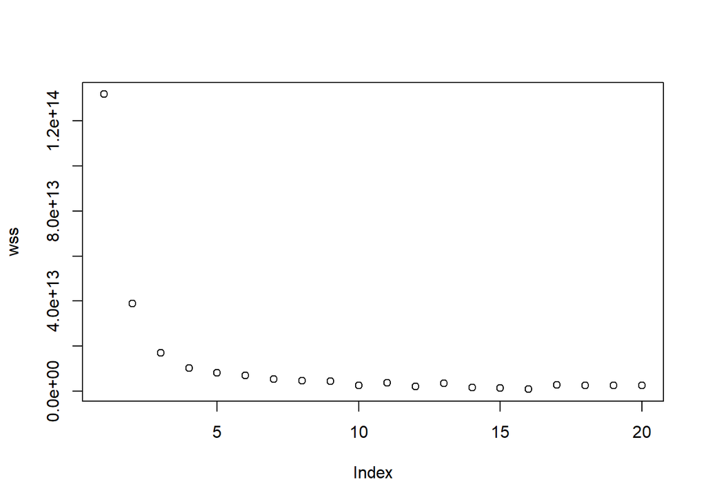

```r
plot(wss)
```

According to the result, I would like to choose 5.

```r
set.seed(0)
cluster.km = kmeans(train.x, 5, nstart = 10)
```

```r
table(cluster.km$cluster)
```

```
##
##    1    2    3    4    5
##    2    9   66    1 3760
```

```r
cluster.km$cluster[3576:3838]
```

```
##   [1] 5 5 5 5 5 5 5 5 5 1 1 5 5 5 5 5 5 5 5 5 5 5 5 5 5 5 5 5 5 5 5 5 5 5 5
##  [36] 5 5 5 5 5 5 5 5 5 5 5 5 5 5 5 5 5 5 5 5 5 5 5 5 5 5 5 5 5 5 5 5 5 5 5
##  [71] 5 5 5 5 5 5 5 5 5 5 5 5 5 5 5 5 5 5 5 5 5 5 5 5 5 5 5 5 5 5 5 5 5 5 5
## [106] 5 5 5 5 2 5 5 5 5 5 5 5 5 5 5 5 5 5 5 5 5 5 5 5 5 5 5 5 5 5 5 5 5 5 5
## [141] 5 5 5 5 5 5 5 5 5 5 5 5 5 5 5 5 5 5 5 5 5 5 5 5 5 5 5 5 5 5 5 5 5 5 5
## [176] 5 5 5 5 5 5 5 5 5 5 5 5 5 5 5 5 5 5 5 5 5 5 5 5 5 5 5 5 5 5 5 5 5 5 5
## [211] 5 5 5 5 5 5 5 5 5 5 5 5 5 5 5 5 5 5 5 5 5 5 5 5 5 5 5 5 5 5 5 5 5 5 5
## [246] 5 5 5 5 5 5 5 5 5 5 5 5 5 5 5 5 5 5
```

```r
cluster.km$cluster[1:200]
```

```
##   [1] 5 5 5 5 5 5 5 5 5 5 5 5 5 5 5 5 5 5 5 5 5 5 5 5 5 5 5 5 5 5 5 5 5 5 5
##  [36] 5 5 5 5 5 5 5 5 5 5 5 5 5 5 5 5 5 5 5 5 5 5 5 5 5 5 5 5 5 5 5 5 5 5 5
##  [71] 5 5 5 5 5 5 5 5 5 5 5 5 5 5 5 5 5 5 5 5 5 5 5 5 5 5 5 5 5 5 5 5 5 5 5
## [106] 5 5 5 5 5 5 5 5 5 5 5 5 5 5 5 5 5 5 5 5 5 5 5 5 5 5 5 5 5 5 5 5 5 5 5
## [141] 5 5 5 5 5 5 5 5 5 5 5 5 5 5 5 5 5 5 5 5 5 5 5 5 5 5 5 5 5 5 3 5 5 5 5
## [176] 5 5 5 5 5 5 5 5 5 5 5 5 5 5 5 5 5 5 5 5 5 5 5 5 5
```

# MDS

```r
dist1 = dist(scale(train.x))
```

```r
cmds2=cmdscale(dist1, k=2, add=T, list. = T)
```

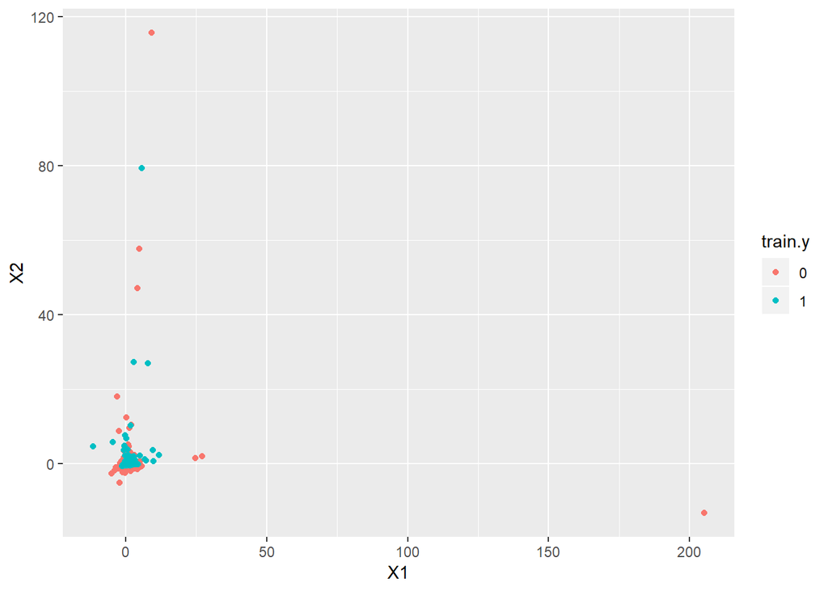

```r
mds_x = data.frame(cmds2$points)
xy = cbind(mds_x, train.y)
ggplot(xy, aes(x=X1,y=X2, colour = train.y))+geom_point()
```

```r
library(rgl)
cmds3=cmdscale(dist1, k=3, add=T, list. = T)
x=cmds3$points[,1]
y=cmds3$points[,2]
z=cmds3$points[,3]
```

I didn’t see the MDS is useful, so I would like to try it on testset.

# K-means and MDS on testset

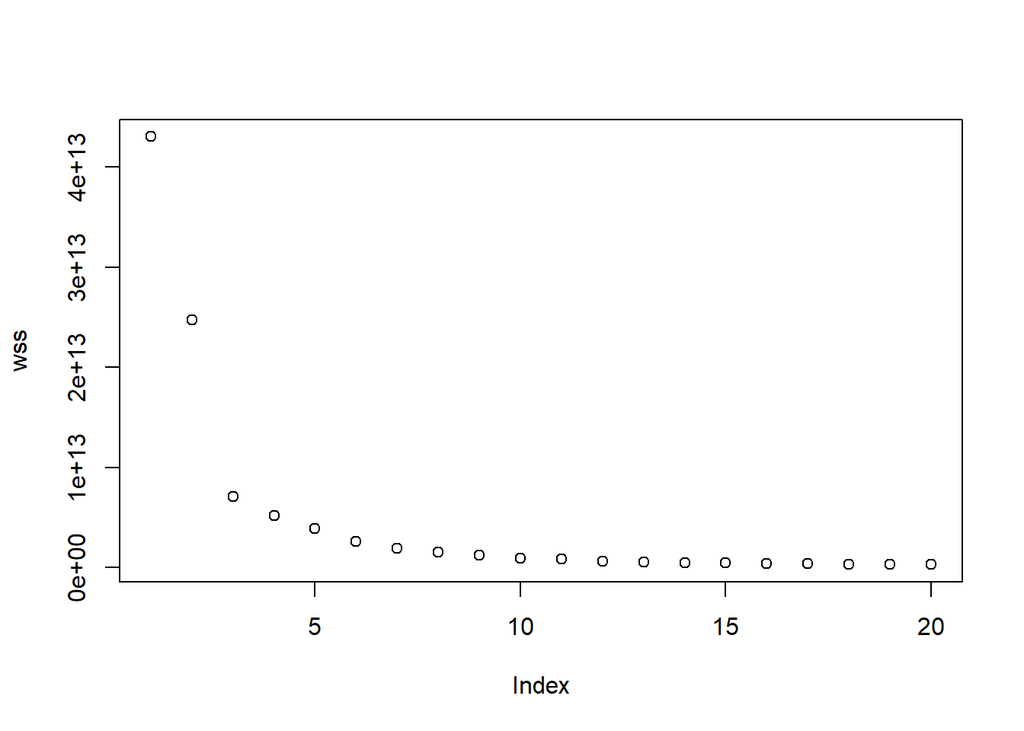

```r
set.seed(0)
wss = rep(0, 20)
for (i in 1:20) {
wss[i] = sum(kmeans(test.x, centers = i, nstart = 10)$tot.withinss)
}
plot(wss)
```

```r
set.seed(0)
cluster.km = kmeans(test.x,7, nstart = 10)
table(cluster.km$cluster)
```

```
##
##    1    2    3    4    5    6    7
##    5    1    1   62    2 1847    1
```

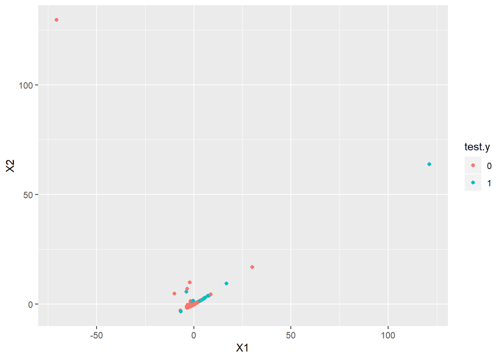

```r
dist2 = dist(scale(test.x))
cmds2=cmdscale(dist2, k=2, add=T, list. = T)
mds_x = data.frame(cmds2$points)
xy = cbind(mds_x, test.y)
ggplot(xy, aes(x=X1,y=X2, colour = test.y))+geom_point()
```

Well, I don’t think MDS performance well in this dataset.